# Ecological Distance and Dissimilarity

#### Material from:

https://www.umass.edu/landeco/teaching/multivariate/schedule/distance.pdf https://www.flutterbys.com.au/stats/tut/tut13.4.html

#### Covering four main type of ecological distance (or dissimilarity):

1. Euclidean Distance 2. Euclidean Distance Based on Species Profiles 3. City-Block (Manhattan) 4. Proporotional Dissimilarity

1 and 2 are related; 3 and 4 are related

#### Background

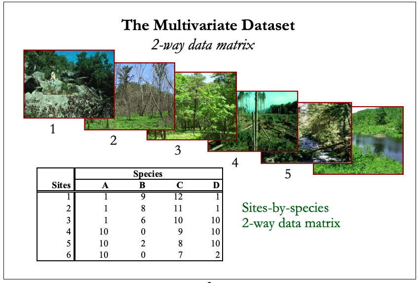

### variables = columns or species

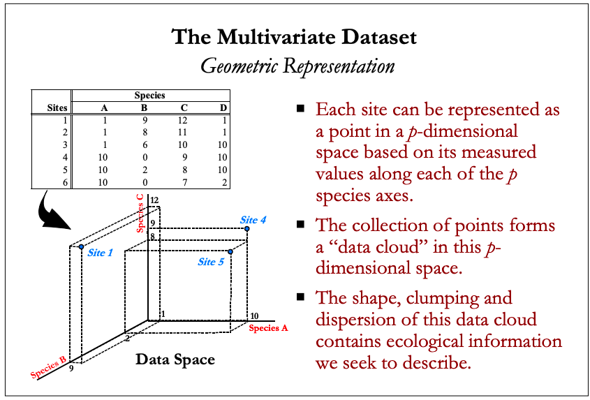

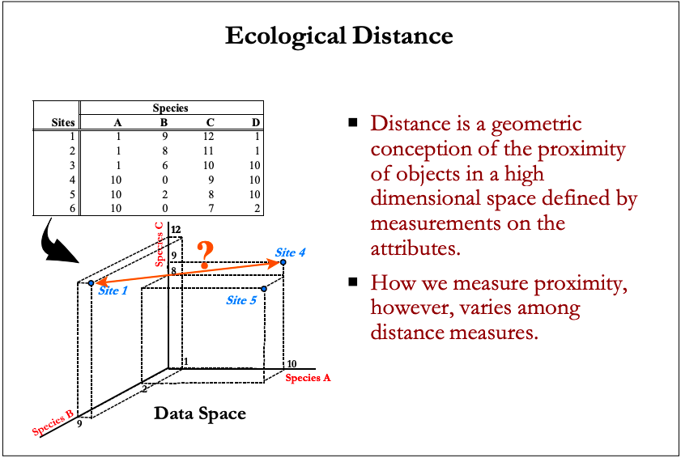

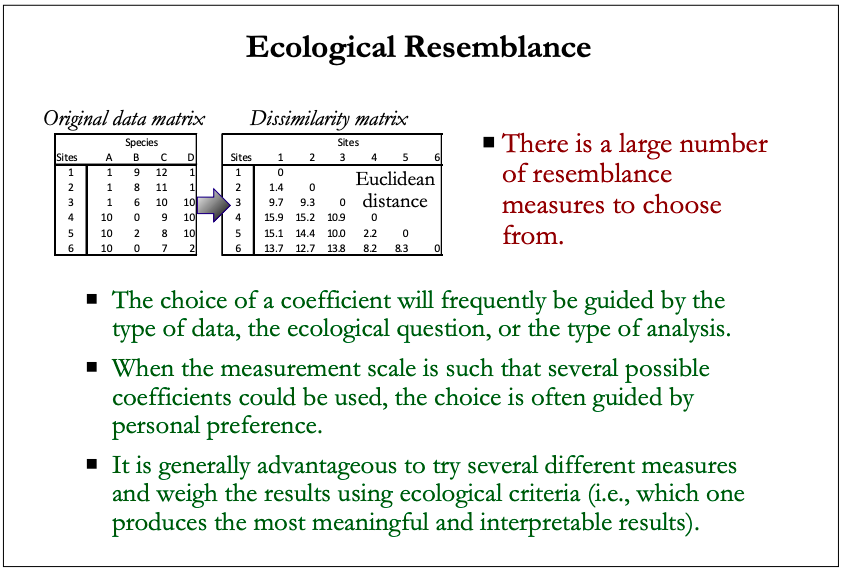

### 0. Create example dataset

```r
library(vegan)
Y <- matrix(c(
2,0,0,5,
13,7,10,5,
9,5,55,93,
10,6,76,81,
0,2,6,0
),5,4, byrow = TRUE)
colnames(Y) <- paste("Species", 1:4, sep = "")
rownames(Y) <- paste("Site", 1:5, sep = "")

Y
```

```
##       Species1 Species2 Species3 Species4
## Site1        2        0        0        5
## Site2       13        7       10        5
## Site3        9        5       55       93
## Site4       10        6       76       81
## Site5        0        2        6        0
```

```r
# sites 3 and 4 should be the most similar
# sites 1 and 5 should be the most dissimilar (they have nothing in common)
# species 1 and 2 as well as 3 and 4 are reasonably well correlated
```

### 1. Euclidean distance

Wikipedia: Euclidean distance between two points in Euclidean space is the length of a line segment between the two points. It can be calculated from the Cartesian coordinates of the points using the Pythagorean theorem, therefore occasionally being called the Pythagorean distance.

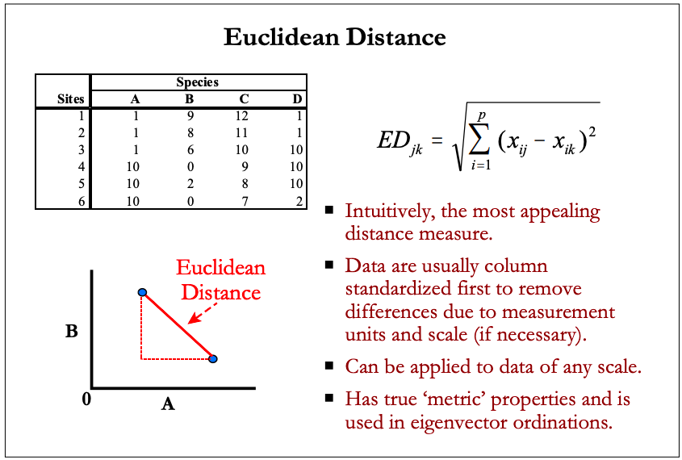

```r
# represents the geometric distance between two points in multidimensional space

# bounded by zero when two objects have identical variable values. no upper bound and the magnitude of the values depends on the scale of the observations as well as the sample size

# useful for representing differences of purely measured variables (of similar scale), for which the simple geometric distances do have real meaning

Y
```

```
##       Species1 Species2 Species3 Species4
## Site1        2        0        0        5
## Site2       13        7       10        5
## Site3        9        5       55       93
## Site4       10        6       76       81
## Site5        0        2        6        0
```

```r
vegdist(Y, method = "euclidean")
```

```
##            Site1      Site2      Site3      Site4
## Site2  16.431677
## Site3 104.129727  98.939375
## Site4 107.944430 100.707497  24.228083
## Site5   8.306624  15.329710 105.546198 107.596468
```

```r
# counter intuitively, sites 1 and 5 of the species abundances are considered the most similar - not desirable as they have nothing in common

# sites 1 and 5 have low species counts and therefore low distances - not desirable for abundance data

### takeaways ###
# not well suited to data such as species abundances (without prior standardizations) due to its lack of a maximum and its high susceptibility to large differences (due to being based on squared differences)
# assumes that variables are uncorrelated (never so)
# emphasizes outliers
# loses sensitivity more rapidly than other distance measures as heterogeneity of data increases
# nonproportional distance measure
```

### 2. Euclidean Distance Based on Species Profiles: χ2 and Hellinger distance

1. All these distance measures work well with species data, preserve the ‘metric’ distance, and are Euclidean
2. Similar conceptually to ED, but the data are adjusted so that the sums of squares for each row are 1 (i.e., row normalization).
3. Useful in species abundance data; effectively removes differences in overall abundances among samples, instead focusing analysis on the differences in relative abundances among species (i.e., species profiles).

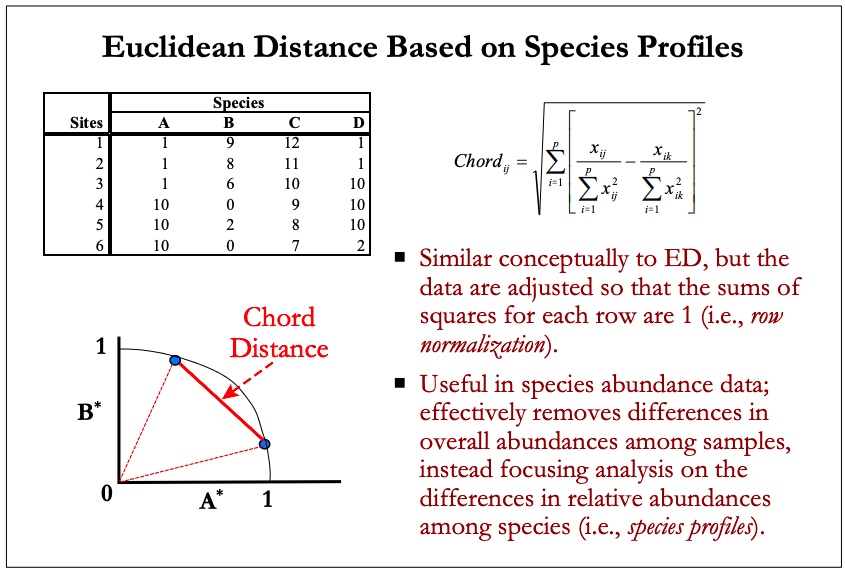

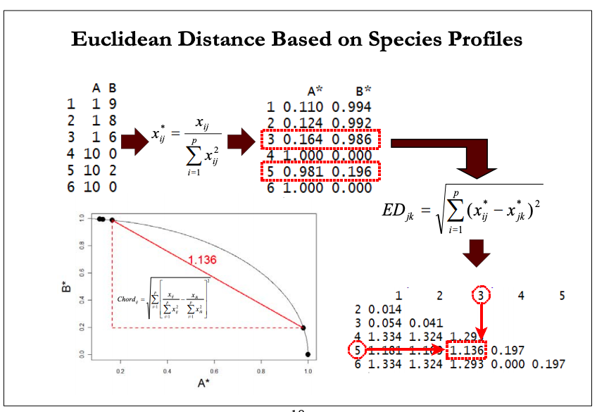

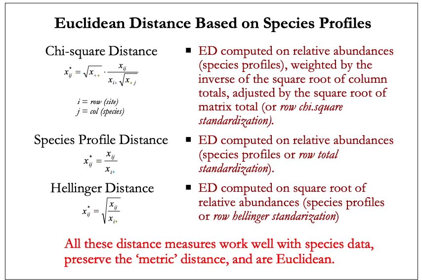

### 2.1 χ2 distance

```r
# distance is essentially the euclidean distances of relative abundances (frequencies rather than raw values) weighted (standardized) by the square root of the inverse of column sums and multiplied by the square root of the total abundances.

# it is only relevant for abundance data for which it is arguably more appropriate than euclidean distances (due to the non-linearity of species abundances)

# as a result of working with relative abundances (frequencies), all sites and species are treated equally - that is, unlike the related euclidean distance, the distance values are not dependent on absolute magnitudes.

Y
```

```
##       Species1 Species2 Species3 Species4
## Site1        2        0        0        5
## Site2       13        7       10        5
## Site3        9        5       55       93
## Site4       10        6       76       81
## Site5        0        2        6        0
```

```r
dist(decostand(Y, method = "chi"))
```

```
##           Site1     Site2     Site3     Site4
## Site2 1.3229599
## Site3 0.9804067 1.4412326
## Site4 1.1151188 1.3867820 0.2233258
## Site5 2.1606146 1.4891531 1.4457654 1.2813310
```

```r
# sites 3 and 4 are considered the most similar and sites 1 and 5 the most dissimiliar (consistent with expectations).

# the units of the distances don't have any real interpretatio
```

### 2.2 Hellinger distance

```r
# the euclidean distances of square root relative abundances (frequencies rather than raw values). Square rooting the frequencies reduces the impacts of relatively abundant species.

# like χ2 distance, the Hellinger distance works on frequencies and therefore is only relevant for abundance data. A Hellinger transformation can be a useful preparation of species abundance data where the abundances are expected to by unimodal

Y
```

```
##       Species1 Species2 Species3 Species4
## Site1        2        0        0        5
## Site2       13        7       10        5
## Site3        9        5       55       93
## Site4       10        6       76       81
## Site5        0        2        6        0
```

```r
dist(decostand(Y, method = "hellinger"))
```

```
##           Site1     Site2     Site3     Site4
## Site2 0.8423744
## Site3 0.6836053 0.5999300
## Site4 0.7657483 0.5608590 0.1092925
## Site5 1.4142136 0.7918120 0.9028295 0.8159425
```

```r
# sites 3 and 4 are considered the most similar and sites 1 and 5 the most dissimiliar (consistent with expectations).

# the units of the distances don't have any real interpretation
```

#### 3. City-Block or Manhattan Distance

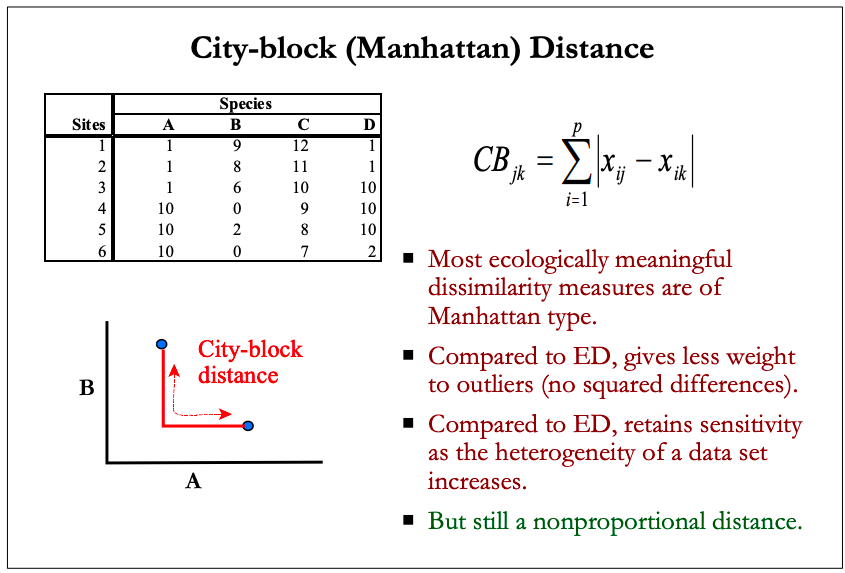

```r
# Manhattan distance the sum of the absolute differences between pairs of variable values. Whilst the Manhattan measure is based on differences rather than squared differences, the magnitude of values still depends on the total abundances even when two sites share no species in common; not bound at the upper end

# City-block (Manhattan) distance measures expressed as proportions of the maximum distance possible. Whereby if two communities share no species in common they have a maximum dissimilarity of one.

Y
```

```
##       Species1 Species2 Species3 Species4
## Site1        2        0        0        5
## Site2       13        7       10        5
## Site3        9        5       55       93
## Site4       10        6       76       81
## Site5        0        2        6        0
```

```r
vegdist(Y,method="manhattan")
```

```
##       Site1 Site2 Site3 Site4
## Site2    28
## Site3   155   139
## Site4   166   146    35
## Site5    15    27   154   165
```

```r
# as with Euclidean distances, sites 1 and 5 of the species abundances are considered the most similar - not desirable as they have nothing in common

# sites 1 and 2 in the environmental data are considered the most similar - although the units of difference don't really have a meaning

### takeaways ###
# compared to euclidean, gives less weight to outliers (no squared differences).
# compared to euclidean, retains sensitivity as the heterogeneity of a data set increases.
# but still a nonproportional distance.
```

[output not shown]

[output not shown]

#### 4. Proportional distance

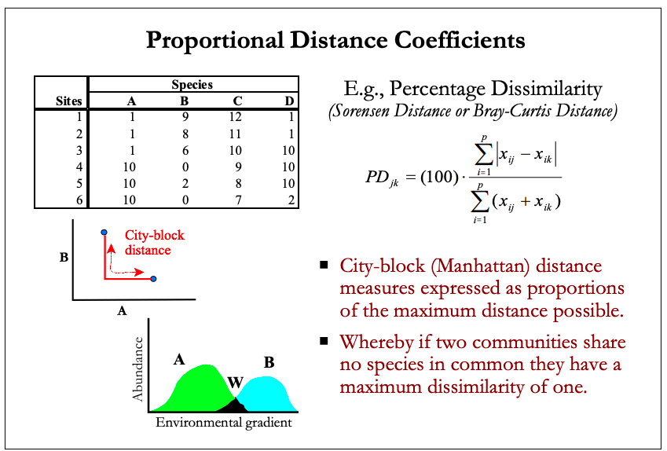

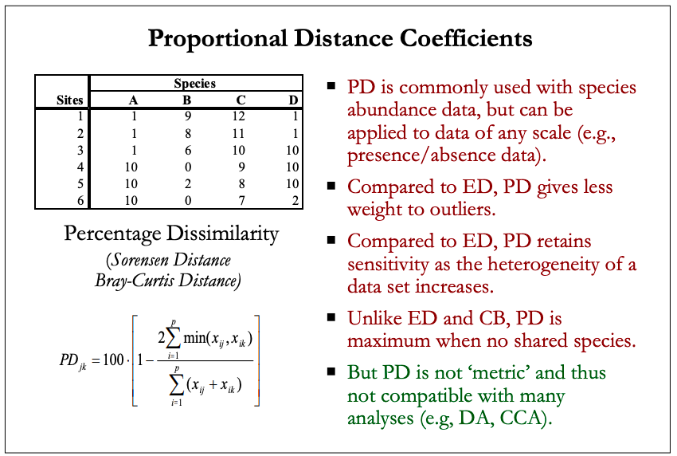

### 4.1 Bray-Curtis dissimilarity

Why “dissimilarity”?

Dissimilarity coefficients: Dissimilarity coefficients are the conceptual (and often mathematical) inverse of similarity coefficients. These reach their maxima when objects share no similar variable values. Dissimilarity measures may or may not be metric. When they are metric, they are more correctly called distance coefficients.

Distance coefficients: A special case of dissimilarity coefficients, distances must satisfy the triangle inequality. This specifies that for any triangle with vertices A, B, and C, the path defined by the line AB is always shorter than the path defined by AC + CB or BC + CA. https://sites.google.com/site/mb3gustame/reference/dissimilarity

Roberts 2017: Warton, Wright & Wang (2012) refer to Euclidean distance, Manhattan distance, Canberra distance and Bray–Curtis distance all as distances despite the fact that the Bray–Curtis dissimilarity has been known for decades not to meet the axioms of a geometric distance that define a metric space (Orlóci 1978). https://besjournals.onlinelibrary.wiley.com/doi/full/10.1111/2041-210X.12739

Wikipedia: The Bray–Curtis dissimilarity is often erroneously called a distance (“A well-defined distance function obeys the triangle inequality, but there are several justifiable measures of difference between samples which do not have this property: to distinguish these from true distances we often refer to them as dissimilarities”[4]). It is not a distance since it does not satisfy triangle inequality, and should always be called a dissimilarity to avoid confusion.

```r
# Bray-Curtis is the Manhattan measure standardized by division with the sum of the pairwise sums. Alternatively, twice the sum of the pairwise minimums, can be used as the numerator.

Y
```

```
##       Species1 Species2 Species3 Species4
## Site1        2        0        0        5
## Site2       13        7       10        5
## Site3        9        5       55       93
## Site4       10        6       76       81
## Site5        0        2        6        0
```

```r
vegdist(Y, method = "bray")
```

```
##           Site1     Site2     Site3     Site4
## Site2 0.6666667
## Site3 0.9171598 0.7055838
## Site4 0.9222222 0.7019231 0.1044776
## Site5 1.0000000 0.6279070 0.9058824 0.9116022
```

```r
# desirably, sites 3 and 4 of the species abundances are considered the most similar and sites 1 and 5 the most dissimilar

# the patterns in the environmental data a consistent with those of Euclidean, yet the units of distance have no meaning (other than as percentage)

### take aways ###
# Bray-Curtis dissimilarities are considered most appropriate for species abundance data as they:
##  reach a maximum value of 1 when two objects have nothing in common
##  ignores joint absences (0's)
##  Nevertheless, it is predominantly influenced by large values, and therefore standardizations are recommended prior to generating a Bray-Curtis dissimilarity.
```

[output not shown]

[output not shown]

Proportional Distance Based on Species Profiles

```r
# PD can be computed on standardized data, similar to chord distance, in which species abundances are divided by sample totals so that each sample contributes equally regardless of total abundance.
# This measure shifts the emphasis of the analysis to proportions of species in a sample unit, rather than absolute abundances.

# calc row sums
row.sums <- rowSums(Y)
row.sums
```

```
## Site1 Site2 Site3 Site4 Site5
##     7    35   162   173     8
```

```r
# standardize column values by sample (row) sums
Y.prop <- Y / row.sums
Y.prop
```

```
##         Species1   Species2  Species3  Species4
## Site1 0.28571429 0.00000000 0.0000000 0.7142857
## Site2 0.37142857 0.20000000 0.2857143 0.1428571
## Site3 0.05555556 0.03086420 0.3395062 0.5740741
## Site4 0.05780347 0.03468208 0.4393064 0.4682081
## Site5 0.00000000 0.25000000 0.7500000 0.0000000
```

```r
# all row sums now equal 1 (i.e., have equal weight)
rowSums(Y.prop)
```

```
## Site1 Site2 Site3 Site4 Site5
##     1     1     1     1     1
```

```r
# compare dissimilarities
Y
```

```
##       Species1 Species2 Species3 Species4
## Site1        2        0        0        5
## Site2       13        7       10        5
## Site3        9        5       55       93
## Site4       10        6       76       81
## Site5        0        2        6        0
```

```r
vegdist(Y.prop, method = "bray")
```

```
##           Site1     Site2     Site3     Site4
## Site2 0.5714286
## Site3 0.3703704 0.4850088
## Site4 0.4739884 0.4789430 0.1058660
## Site5 1.0000000 0.5142857 0.6296296 0.5260116
```

```r
vegdist(Y, method = "bray")
```

```
##           Site1     Site2     Site3     Site4
## Site2 0.6666667
## Site3 0.9171598 0.7055838
## Site4 0.9222222 0.7019231 0.1044776
## Site5 1.0000000 0.6279070 0.9058824 0.9116022
```

```r
# 3 and 4 still most similar
# 1 and 5 still most dissimilar
# differences in other sites though
```

#### Compares Dissimilarity Indices for Gradient Detection

```r
# copied and pasted from:
help("rankindex")

data(varespec)
data(varechem)
## The variables are automatically scaled
rankindex(varechem, varespec)
```

```
##       euc       man       gow       bra       kul
## 0.2396330 0.2735087 0.2288358 0.2837910 0.2839834
```

```r
rankindex(varechem, wisconsin(varespec))
```

```
##       euc       man       gow       bra       kul
## 0.4200990 0.4215642 0.3708606 0.4215642 0.4215642
```

```r
## Using non vegdist indices as functions
funs <- list(Manhattan=function(x) dist(x, "manhattan"),
    Gower=function(x) cluster:::daisy(x, "gower"),
    Ochiai=function(x) designdist(x, "1-J/sqrt(A*B)"))
rankindex(scale(varechem), varespec, funs)
```

```
## Manhattan     Gower    Ochiai
## 0.2735087 0.2288358 0.1696862
```

This wizard is based on Tables 7.3, 7.4, and 7.5 of Legendre and Legendre (1998). It is not exhaustive with respect to the range of (dis)similarity measures available, but will attempt to direct you to an initial solution. https://sites.google.com/site/mb3gustame/wizards/-dis-similarity-wizard